# Project 1: History of Philosophy

A View at Philosophy Throughout the Years

Alix F. Leon - afl2124

Sep. 21, 2022

Philosophy has played a signifficant roll throughout human history. It is an attempt at understanding knowledge, nature, reality, values, ethics, among many other aspects of our lives through the use rational thought. Many of whom we now consider some of the greatest minds have participated in philosophical reasoning, and published their ideas in an effort to immortalize their findings. Consequently, many other authors have published a plethora of philosophical ideas regarding the vast multitude of human concerns leading to creation of several philosophical schools of thought.

This analysis will take at look at philosophical texts from 13 philosophical schools of thought. The data for this analysis was extracted from the [History of philosophy](https://www.kaggle.com/datasets/kouroshalizadeh/history-of-philosophy) dataset. Although many sophisticated models can be used in conjunction with this data, we will use a more traditional approach, using statistical analyses and plots to observe trends, and ultimately support the story.

## Dark ages

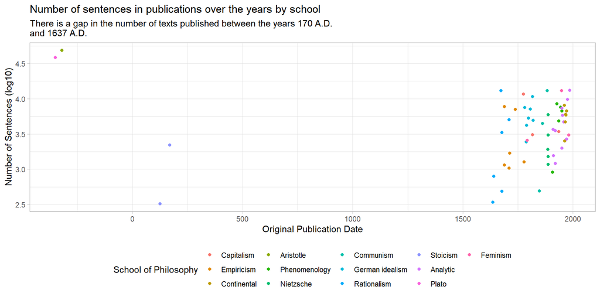

Although the data does not represent a complete picture of philosophical texts published throughout the years, we can see from the plot above that there have been several instances in which barely any texts have been published. Despite the influence of philosphy over the course of history, there have been some “pathches” along the way.

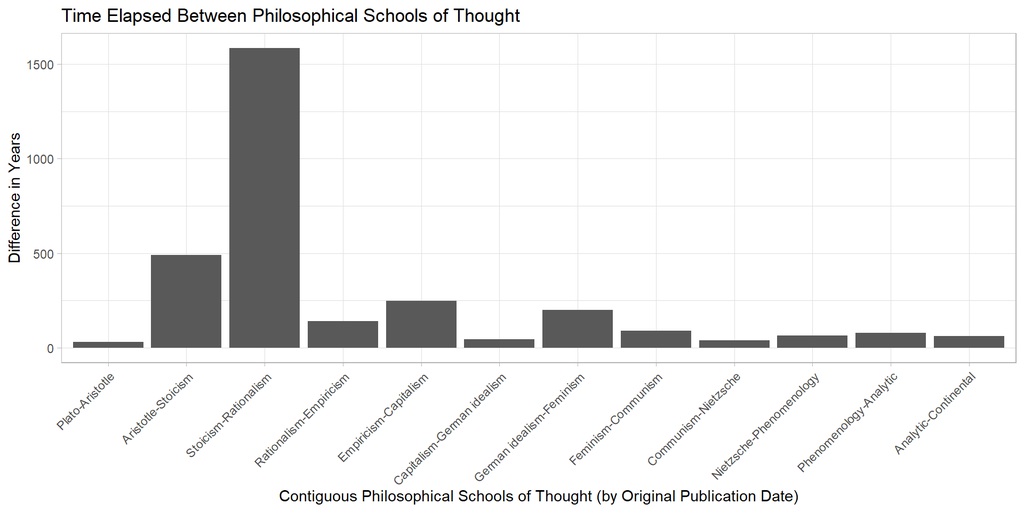

The chart above effectively shows that there is a margin of ~500 years between publication for the school of Aristotle and the school of Stoicism, and more noticeably, a difference of more than ~1,500 years between publications from the school of Stoicism and the school of Rationalism. This gap aligns with a time period in history called the [early middle ages](https://en.wikipedia.org/wiki/Early_Middle_Ages). During this time period, there was a signifficant reduction in the number of philosophical publications¹.

**Source:** [A companion to philosophy in the Middle Ages. Blackwell Pub.](https://books.google.com/books?id=hRJT7O-uNooC&lpg=PA1&ots=Ddy7vORhhG&dq=middle%20ages%20philosophy&lr&pg=PA1#v=onepage&q=middle%20ages%20philosophy&f=false)

## Sentence Length

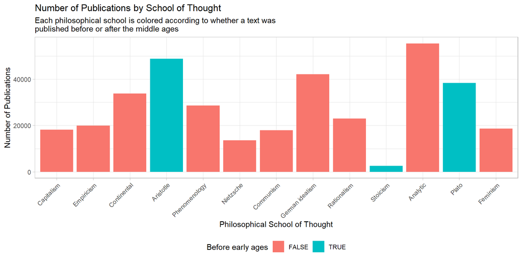

Philosophical texts, both during the modern age and during its beginnings, tend to be very dense. For instance, the works of authors before the middle ages combined account for more than 89 thousand sentences. In other words, these publications from the aforementioned schools account for roughly 24.85% of the sentences contained in the dataset.

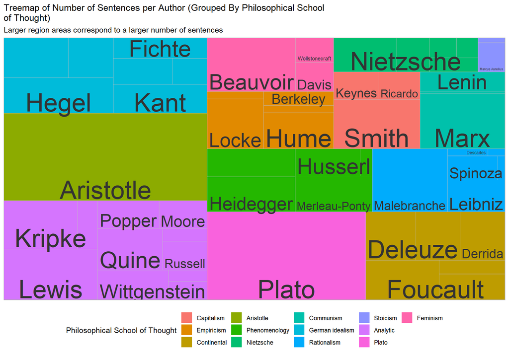

This treemap shows how different authors compare in terms of sentence length. The regions are divided by their respective philosophical schools of thought. We can see that some of the largest publications (by sentence size) were written by philosophers such as Aristotle, Plato, Lewis, Marx, etc. The works of these authors are some of the most influential publications in philosophical history, and have made major impacts on areas outside of philosophy. For instance, *The Complete Works* of Aristotle in many ways shaped the future of academia and influenced the works of many others.

## Sentiment Analysis

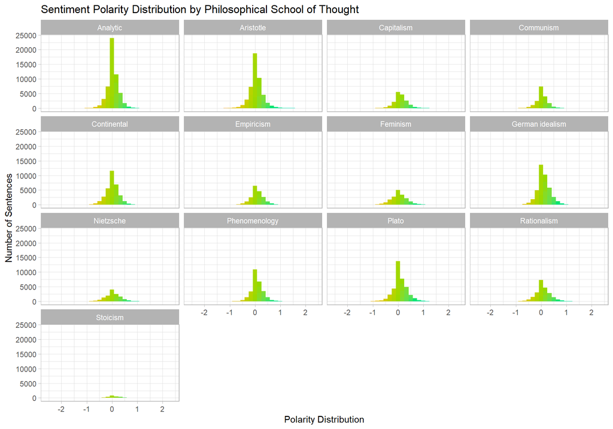

The principles of philosophical texts are based on logical reasoning applied to different types of problems. The histograms above display the distribution of the average sentiment score applied to the sentences for each philosophical school. We can see that each of these distributions is centered around 0, with the mode of each being around this neighborhood, further supporting our claim.